# Problem set 2

Bailey Kretzler

9/28/2020

**Problem 1: exponential growth in cancer**

Single cancer cell in the colon growing at *exponential rate*

Average doubling time of 109 days

lethal size = 1x10 ^12

When will it reach lethal size?

```r
P0 = 1 # initial population of 1 cell
r = 0.00635915
exp(2)  # = e^2
```

```
## [1] 7.389056
```

```r
t_max = 12000



P = vector("numeric", length = t_max)

for (t in 1:t_max ) {
  P[t] = P0*exp(r*t)
}

exp(1)
```

```
## [1] 2.718282
```

```r
tail(P)
```

```
## [1] 1.340036e+33 1.348584e+33 1.357187e+33 1.365845e+33 1.374559e+33
## [6] 1.383328e+33
```

```r
dfP <- as.data.frame(P)

Psol <- subset(dfP, dfP$P >= 1000000000000)
head(Psol)
```

```
##                 P
## 4346 1.005862e+12
## 4347 1.012279e+12
## 4348 1.018736e+12
## 4349 1.025235e+12
## 4350 1.031776e+12
## 4351 1.038358e+12
```

It will take 4346 days for the population to reach a size of 1 x 10^12. This is nearly 12 years or 40 doubling cycles.

**Problem 2: Sterile Insect Release**

find the equilibrium point for equation below:

dN/dt = b(N/(N+M))- d

equilibrium exists when growth point = 0

*Finding the equilibrium point*

We first set the equation for growth rate equal to 0, with the value *N<sub>bar</sub>*

$$\frac{dN}{dt} = 0 = b \frac{N_{bar}}{N_{bar}+M} -d$$
Some algebra to isolate the fraction (add *d* and divide out *b*)

$$\frac{d}{b} = \frac{N_{bar}}{N_{bar}+M}$$
this is the same as
$$\frac{b}{d} = 1+ \frac{M}{N_{bar}}$$
We then subtract 1 and divide by *N<sub>bar</sub>* to obtain:

$$N_{bar}(\frac{b}{d} - 1) = M$$
We can rearrange to solve for *N<sub>bar</sub>*:

$$N_{bar}= \frac{M} {(\frac{b}{d} - 1)}$$
This is our equilibrium point. We now need to derive the *dN/dt* equation to find the stability equation.

*Stability equation*

In order to do this we need to use the quotient rule as illustrated below

$$\frac{d}{dN}(\frac{bN}{N+M}) - \frac{d}{dN}(d)$$

The derivative of *d* is 0 so this drops from the equation. On the remainder we deploy the quotient rule and end up with the following:

$$b * \frac{(1*(N+M)) - N(1)}{(N+M)^2}$$
This simplifies down to

$$b* \frac{M}{(N+M)^2}$$

to determine if the equilibrium point is stable we need to plug it in to this equation:

$$b* \frac{M}{(\frac{M} {(\frac{b}{d} - 1)}+M)^2}$$

This equilibrium is not stable. Regardless of the terms in put, they will not result in a value less than 0 unless birthrate is negative, as number of males in the numerator cannot be negative and the squared terms in the denominator also cannot be negative.

This relates to the Allee effect as when the number of sterile male increases, this will crowd out the fertile male population. This limits any positive density dependence effect the sterile males could have.

**Question 3**

```r
require(deSolve)
```

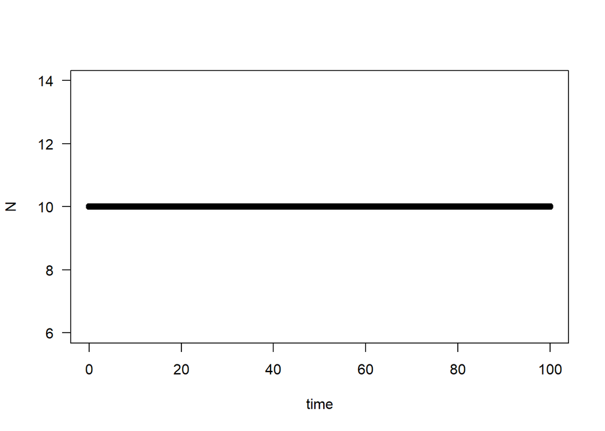

```r
## Loading required package: deSolve
# Initial values
state <- c(N=10)
times <- seq(0,100,by=0.1)

# Parameters
parameters <- c(b = 2.4,c=0.02,M=50,d=0.2)

# Model
sterile_insect <- function(t,state,parameters){
  with(as.list(c(state,parameters)),{
       dN <- b*N/(N+M) - d - c*N
      list(c(dN))
  })}

# Solve model and plot results
out <- ode(y = state,times=times,func=sterile_insect,parms=parameters)
par(mfrow=c(1,1))
plot(out[,1],out[,2],ylab='N',xlab='time',las=1)
```

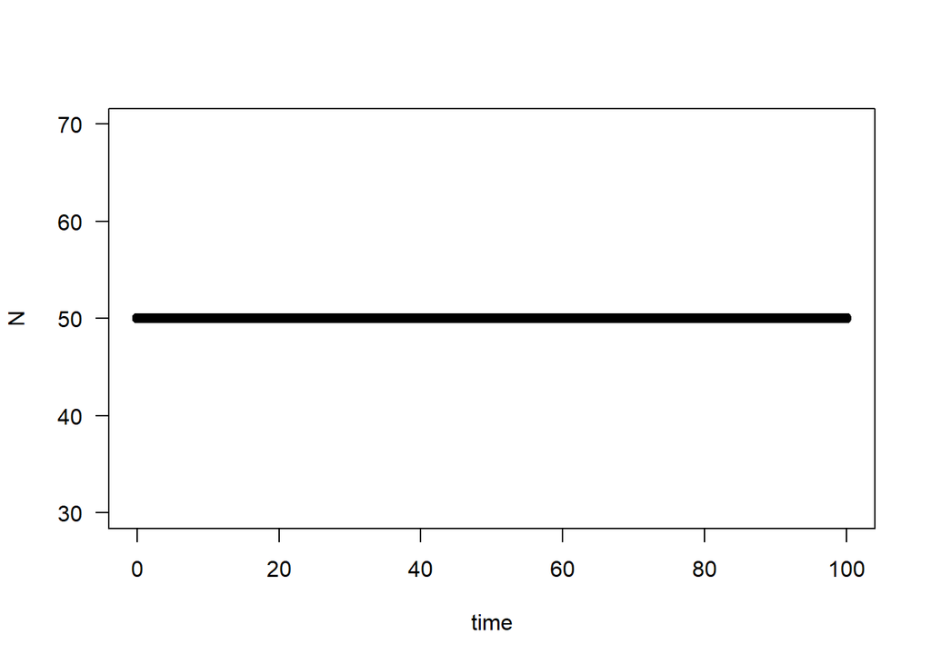

```r
require(deSolve)
## Loading required package: deSolve
# Initial values
state <- c(N=50)
times <- seq(0,100,by=0.1)

# Parameters
parameters <- c(b = 2.4,c=0.02,M=50,d=0.2)

# Model
sterile_insect <- function(t,state,parameters){
  with(as.list(c(state,parameters)),{
       dN <- b*N/(N+M) - d - c*N
      list(c(dN))
  })}

# Solve model and plot results
out <- ode(y = state,times=times,func=sterile_insect,parms=parameters)
par(mfrow=c(1,1))
plot(out[,1],out[,2],ylab='N',xlab='time',las=1)
```

When N = both 10 and 50 the product is a stable line at these N values across time indicating that they are equilibrium points. 10 is unstable and 50 is stable. Anything above and below 50 moves back to 50, whereas anything above and below 10 moves away from 10 to either extinction or the 50 equilibrium point. This can be determined by examining the graph below or graphs at different N values surrounding each point.

*creating a for loop to plot N vs dN*

```r
b = 2.4
c=0.02
M=50
d=0.2
maxN = 100
dN = vector(length = maxN)


for (N in 1:maxN){
  dN[N] <- b*N/(N+M) - d - c*N
}

dN
```

```
##   [1] -0.172941176 -0.147692308 -0.124150943 -0.102222222 -0.081818182
##   [6] -0.062857143 -0.045263158 -0.028965517 -0.013898305  0.000000000
##  [11]  0.012786885  0.024516129  0.035238095  0.045000000  0.053846154
##  [16]  0.061818182  0.068955224  0.075294118  0.080869565  0.085714286
##  [21]  0.089859155  0.093333333  0.096164384  0.098378378  0.100000000
##  [26]  0.101052632  0.101558442  0.101538462  0.101012658  0.100000000
##  [31]  0.098518519  0.096585366  0.094216867  0.091428571  0.088235294
##  [36]  0.084651163  0.080689655  0.076363636  0.071685393  0.066666667
##  [41]  0.061318681  0.055652174  0.049677419  0.043404255  0.036842105
##  [46]  0.030000000  0.022886598  0.015510204  0.007878788  0.000000000
##  [51] -0.008118812 -0.016470588 -0.025048544 -0.033846154 -0.042857143
##  [56] -0.052075472 -0.061495327 -0.071111111 -0.080917431 -0.090909091
##  [61] -0.101081081 -0.111428571 -0.121946903 -0.132631579 -0.143478261
##  [66] -0.154482759 -0.165641026 -0.176949153 -0.188403361 -0.200000000
##  [71] -0.211735537 -0.223606557 -0.235609756 -0.247741935 -0.260000000
##  [76] -0.272380952 -0.284881890 -0.297500000 -0.310232558 -0.323076923
##  [81] -0.336030534 -0.349090909 -0.362255639 -0.375522388 -0.388888889
##  [86] -0.402352941 -0.415912409 -0.429565217 -0.443309353 -0.457142857
##  [91] -0.471063830 -0.485070423 -0.499160839 -0.513333333 -0.527586207
##  [96] -0.541917808 -0.556326531 -0.570810811 -0.585369128 -0.600000000
```

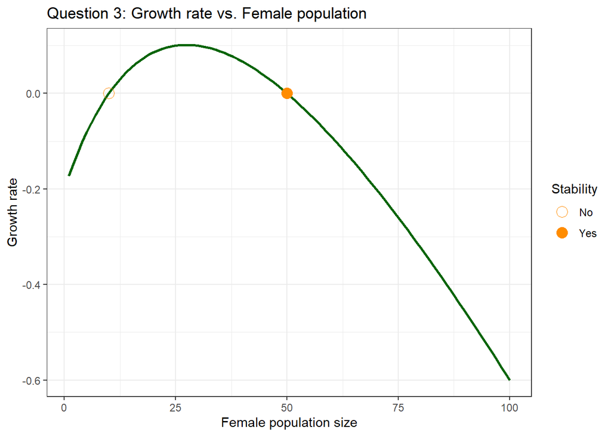

```r
dNdf = as.data.frame(dN)
Nvec <- c(1:100)

dNdf <- cbind(Nvec,dNdf)

require(ggplot2)
subdN <- data.frame(Nvec = c(10,50), dN = c(0,0), Stability = c("No", "Yes"))


ggplot(dNdf, aes(x = Nvec, y = dN)) + geom_line(data = dNdf, aes(Nvec, dN), inherit.aes = T, colour = "dark green", size = 1) + theme_bw() +
  geom_point(data = subdN, aes(x = Nvec, y = dN, shape = Stability),colour = "dark orange", size = 4) + scale_shape_manual(values = c(1, 16)) + labs(x = "Female population size", y = "Growth rate") + ggtitle("Question 3: Growth rate vs. Female population")
```